# GROWING HOPE

- Show All Code
- Hide All Code
- View Source

**Understanding Child Growth & HIV Awareness Worldwide**

Author

Lukman Khiruddin

Published

April 22, 2025

## Introduction

In every corner of our world, the journey of childhood unfolds with both promise and pitfalls. Where the glow of hope is often shadowed by the realities of stunted growth and the silent spread of HIV.

This dashboard invites you to explore the global landscape of child development, weaving together vivid data on child stunting and HIV awareness to reveal the stark contrasts and hidden connections shaping young lives.

```r
library(dplyr)
library(readr)
library(maps)
library(ggplot2)
```

## HIV Knowledge Among Youth by Country

This comparison highlights the percentage of young people (aged 15–24) who possess comprehensive, correct knowledge of HIV across countries. By displaying both the leaders and laggards, we can better understand the global disparities in HIV education. This helps policymakers identify both success stories to emulate and areas where urgent action is needed.

**Top 5 Countries**

**Show code for top countries chart**

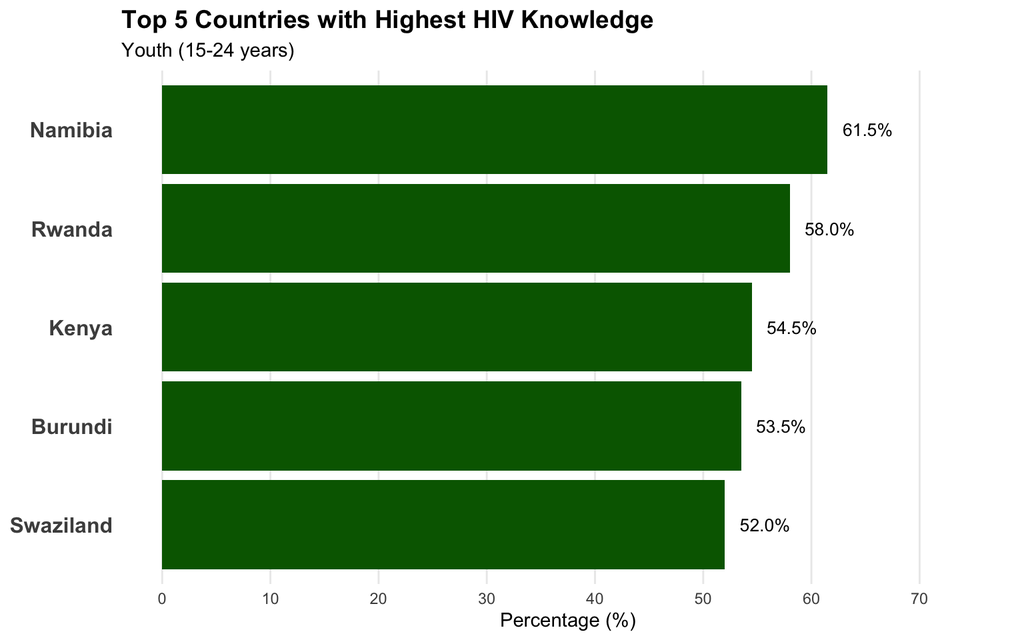

```r
library(ggplot2)
library(dplyr)


combined_indicators <- read_csv("Indicator_Combined.csv")


hiv_knowledge_data <- combined_indicators %>%
    filter(grepl("comprehensive, correct knowledge of HIV", indicator)) %>%
    filter(!is.na(obs_value))


recent_hiv_knowledge <- hiv_knowledge_data %>%
    group_by(country, sex) %>%
    arrange(desc(time_period)) %>%
    slice(1) %>%
    ungroup()


avg_hiv_knowledge <- recent_hiv_knowledge %>%
    group_by(country) %>%
    summarize(avg_knowledge = mean(obs_value, na.rm = TRUE)) %>%
    arrange(desc(avg_knowledge))


top_5_countries <- head(avg_hiv_knowledge, 5)


top_chart <- ggplot(top_5_countries, aes(x = avg_knowledge, y = reorder(country,
    avg_knowledge))) + geom_bar(stat = "identity", fill = "darkgreen") +
    geom_text(aes(label = sprintf("%.1f%%", avg_knowledge)),
        hjust = -0.3, size = 3.5, color = "black") + labs(title = "Top 5 Countries with Highest HIV Knowledge",
    subtitle = "Youth (15-24 years)", x = "Percentage (%)", y = NULL) +
    theme_minimal() + theme(plot.title = element_text(face = "bold",
    size = 14), axis.text.y = element_text(size = 12, face = "bold"),
    panel.grid.major.y = element_blank(), panel.grid.minor.x = element_blank()) +
    scale_x_continuous(limits = c(0, 75), breaks = seq(0, 70,
        by = 10))


print(top_chart)
```

**Bottom 5 Countries**

**Show code for bottom countries chart**

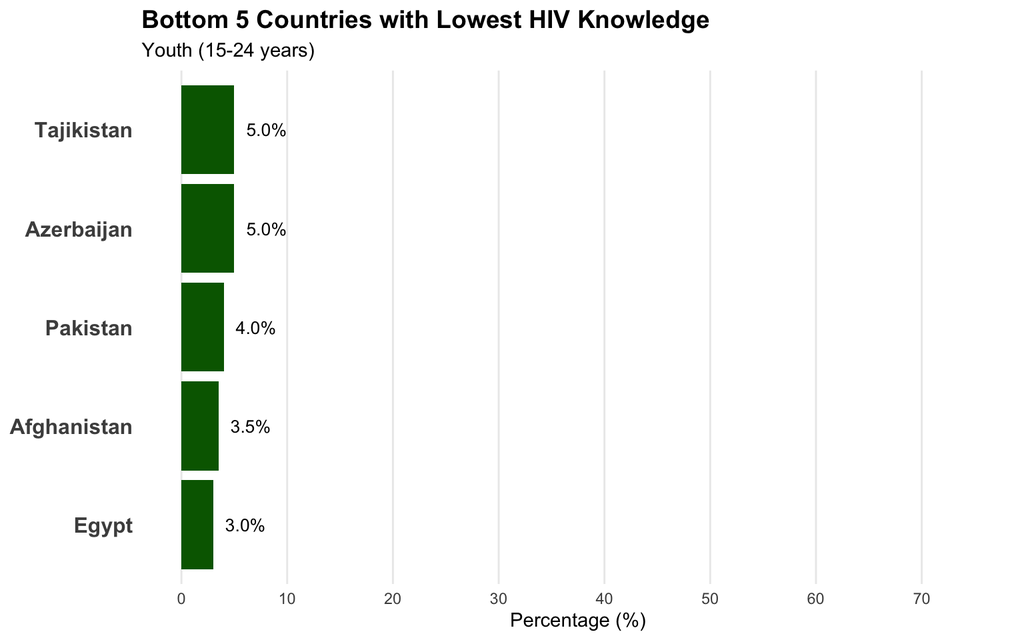

```r
bottom_5_countries <- tail(avg_hiv_knowledge, 5)


bottom_chart <- ggplot(bottom_5_countries, aes(x = avg_knowledge,
    y = reorder(country, avg_knowledge))) + geom_bar(stat = "identity",
    fill = "darkgreen") + geom_text(aes(label = sprintf("%.1f%%",
    avg_knowledge)), hjust = -0.3, size = 3.5, color = "black") +
    labs(title = "Bottom 5 Countries with Lowest HIV Knowledge",
        subtitle = "Youth (15-24 years)", x = "Percentage (%)",
        y = NULL) + theme_minimal() + theme(plot.title = element_text(face = "bold",
    size = 14), axis.text.y = element_text(size = 12, face = "bold"),
    panel.grid.major.y = element_blank(), panel.grid.minor.x = element_blank()) +
    scale_x_continuous(limits = c(0, 75), breaks = seq(0, 70,
        by = 10))


print(bottom_chart)
```

This significant gap (over 55 percentage points between highest and lowest) highlights implementation disparities in HIV education programs worldwide. Countries at the bottom of the ranking could benefit from adapting successful education strategies from top-performing nations.

## Top 4 Countries with HIV Knowledge Trends Over Time

This line chart tracks the evolution of HIV knowledge among males and females in 4 countries over time. The visual uncovers whether both genders are benefiting equally from education efforts, and whether progress is steady, stagnant, or declining. It provides a clear picture of gender gaps and helps guide future interventions to ensure no one is left behind.

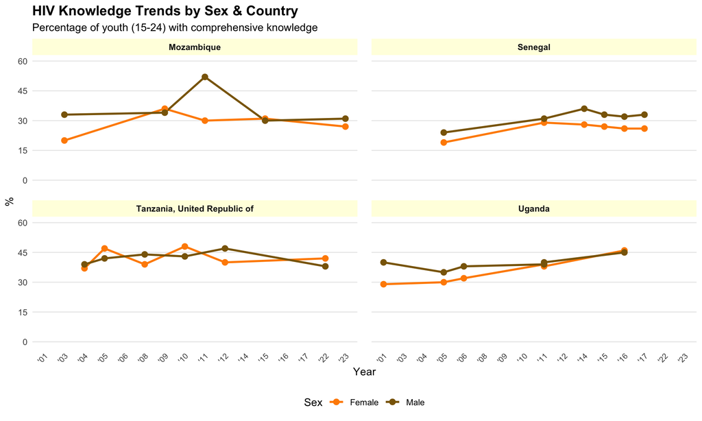

```r
combined_indicators <- read_csv("Indicator_Combined.csv")

hiv_knowledge_data <- combined_indicators %>%
    filter(grepl("comprehensive, correct knowledge of HIV", indicator)) %>%
    filter(!is.na(obs_value)) %>%
    filter(sex %in% c("Female", "Male"))

country_data_counts <- hiv_knowledge_data %>%
    group_by(country, sex) %>%
    summarize(data_points = n(), .groups = "drop") %>%
    group_by(country) %>%
    summarize(total_points = sum(data_points), has_both_sexes = n() >
        1) %>%
    filter(has_both_sexes) %>%
    arrange(desc(total_points))


top_trend_countries <- head(country_data_counts$country, 4)


trend_data <- hiv_knowledge_data %>%
    filter(country %in% top_trend_countries)


trend_data$time_period <- as.character(trend_data$time_period)


trend_data <- trend_data %>%
    mutate(year_short = paste0("'", substr(time_period, 3, 4)))


hiv_trend_chart <- ggplot(trend_data, aes(x = year_short, y = obs_value,
    color = sex, group = interaction(country, sex))) + geom_line(size = 1) +
    geom_point(size = 2.5) + facet_wrap(~country, ncol = 2) +
    scale_color_manual(values = c(Female = "darkorange", Male = "darkgoldenrod4")) +
    # Use scale_x_discrete since years are discrete values
scale_x_discrete() + labs(title = "HIV Knowledge Trends by Sex & Country",
    subtitle = "Percentage of youth (15-24) with comprehensive knowledge",
    x = "Year", y = "%", color = "Sex") + theme_minimal() + theme(plot.title = element_text(face = "bold",
    size = 14), legend.position = "bottom", panel.grid.minor = element_blank(),
    panel.grid.major.x = element_blank(), strip.background = element_rect(fill = "lightyellow",
        color = NA), strip.text = element_text(face = "bold"),
    axis.text.x = element_text(angle = 45, hjust = 1, size = 8),
    axis.title = element_text(size = 11), panel.spacing = unit(1,
        "lines")) + scale_y_continuous(limits = c(0, 60), breaks = seq(0,
    60, by = 15))

print(hiv_trend_chart)
```

This line chart reveals the evolution of HIV knowledge among young people across countries with the richest trend data, showing patterns of change over time for both males and females.

## Global Gender Gap in HIV Knowledge

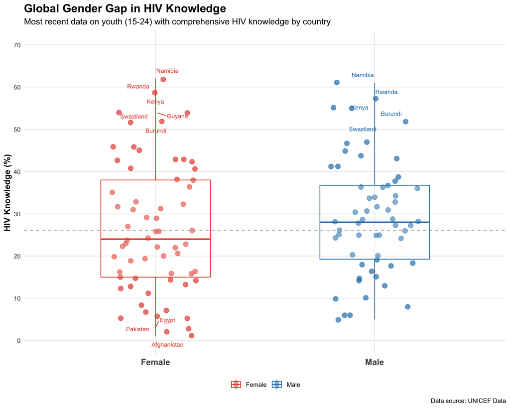

```r
# Load necessary libraries
library(ggplot2)
library(dplyr)
library(ggrepel)

combined_indicators <- read_csv("Indicator_Combined.csv")

hiv_knowledge_global <- combined_indicators %>%
    filter(grepl("comprehensive, correct knowledge of HIV", indicator)) %>%
    filter(!is.na(obs_value)) %>%
    filter(sex %in% c("Female", "Male")) %>%
    group_by(country, sex) %>%
    arrange(desc(time_period)) %>%
    slice(1) %>%
    ungroup()

scatter_plot <- ggplot(hiv_knowledge_global, aes(x = sex, y = obs_value,
    color = sex)) + geom_jitter(size = 3, alpha = 0.7, width = 0.2) +
    geom_boxplot(alpha = 0.2, width = 0.5) + geom_hline(yintercept = median(hiv_knowledge_global$obs_value),
    linetype = "dashed", color = "darkgray") + geom_text_repel(data = hiv_knowledge_global %>%
    filter(obs_value > 50 | obs_value < 5), aes(label = country),
    size = 3, box.padding = 0.5, point.padding = 0.3, max.overlaps = 15,
    show.legend = FALSE) + scale_color_manual(values = c(Female = "#e74c3c",
    Male = "#2980b9")) + labs(title = "Global Gender Gap in HIV Knowledge",
    subtitle = "Most recent data on youth (15-24) with comprehensive HIV knowledge by country",
    y = "HIV Knowledge (%)", x = NULL, caption = "Data source: UNICEF Data") +
    theme_minimal() + theme(plot.title = element_text(face = "bold",
    size = 16), plot.subtitle = element_text(size = 12), legend.position = "bottom",
    legend.title = element_blank(), panel.grid.minor = element_blank(),
    axis.title.y = element_text(face = "bold", size = 12), axis.text.x = element_text(size = 12,
        face = "bold")) + scale_y_continuous(limits = c(0, 70),
    breaks = seq(0, 70, by = 10))

print(scatter_plot)
```

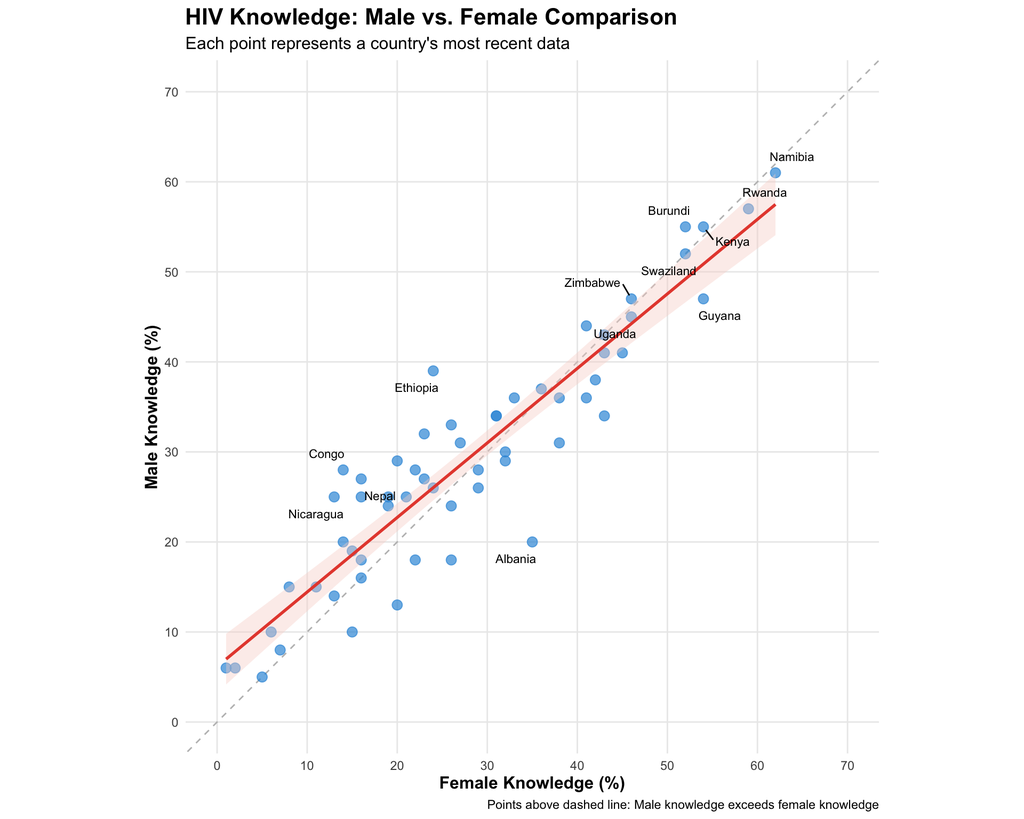

```r
country_comparison <- hiv_knowledge_global %>%
    select(country, sex, obs_value) %>%
    tidyr::pivot_wider(names_from = sex, values_from = obs_value) %>%
    filter(!is.na(Female) & !is.na(Male))

comparison_plot <- ggplot(country_comparison, aes(x = Female,
    y = Male)) + geom_abline(intercept = 0, slope = 1, linetype = "dashed",
    color = "gray") + geom_point(size = 3, alpha = 0.7, color = "#3498db") +
    geom_smooth(method = "lm", se = TRUE, color = "#e74c3c",
        fill = "#f8d5ce") + geom_text_repel(data = country_comparison %>%
    filter(abs(Male - Female) > 10 | Female > 45 | Male > 45),
    aes(label = country), size = 3, box.padding = 0.5, point.padding = 0.3,
    max.overlaps = 10, show.legend = FALSE) + labs(title = "HIV Knowledge: Male vs. Female Comparison",
    subtitle = "Each point represents a country's most recent data",
    x = "Female Knowledge (%)", y = "Male Knowledge (%)", caption = "Points above dashed line: Male knowledge exceeds female knowledge") +
    theme_minimal() + theme(plot.title = element_text(face = "bold",
    size = 16), plot.subtitle = element_text(size = 12), panel.grid.minor = element_blank(),
    axis.title = element_text(face = "bold", size = 12)) + scale_x_continuous(limits = c(0,
    70), breaks = seq(0, 70, by = 10)) + scale_y_continuous(limits = c(0,
    70), breaks = seq(0, 70, by = 10)) + coord_fixed()

print(comparison_plot)
```

These findings highlight the need for targeted educational interventions that address gender-specific barriers to HIV knowledge, with particular attention to countries and regions where overall knowledge levels remain low.

## Child Stunting Burden by Country

**Africa**

[figure not shown]

```r
# Load necessary packages
library(ggplot2)
library(dplyr)
library(maps)

combined_indicators <- read_csv("Indicator_Combined.csv")


stunting_data <- combined_indicators %>%
  filter(grepl("height.for.age", indicator, ignore.case = TRUE) |
         grepl("stunting", indicator, ignore.case = TRUE)) %>%
  filter(!is.na(obs_value)) %>%

  filter(sex == "Total" | is.na(sex))


recent_stunting <- stunting_data %>%
  group_by(country) %>%
  arrange(desc(time_period)) %>%
  slice(1) %>%
  ungroup() %>%
  select(country, obs_value)


africa_map <- map_data("world", region = c(
  # North Africa
  "Algeria", "Egypt", "Libya", "Morocco", "Tunisia", "Sudan", "South Sudan",
  # West Africa
  "Benin", "Burkina Faso", "Cape Verde", "Ivory Coast", "Gambia", "Ghana",
  "Guinea", "Guinea-Bissau", "Liberia", "Mali", "Mauritania", "Niger",
  "Nigeria", "Senegal", "Sierra Leone", "Togo",
  # Central Africa
  "Cameroon", "Central African Republic", "Chad", "Democratic Republic of the Congo",
  "Republic of Congo", "Equatorial Guinea", "Gabon", "Sao Tome and Principe",
  # East Africa
  "Burundi", "Comoros", "Djibouti", "Ethiopia", "Eritrea", "Kenya", "Madagascar",
  "Malawi", "Mauritius", "Mozambique", "Rwanda", "Seychelles", "Somalia",
  "Tanzania", "Uganda", "Zambia", "Zimbabwe",
  # Southern Africa
  "Angola", "Botswana", "Lesotho", "Namibia", "South Africa", "eSwatini"
))


country_mapping <- c(
  "Congo, Democratic Republic of the" = "Democratic Republic of the Congo",
  "Congo, the Democratic Republic of the" = "Democratic Republic of the Congo",
  "Congo" = "Republic of Congo",
  "Tanzania, United Republic of" = "Tanzania",
  "Swaziland" = "eSwatini",
  "Ivory Coast" = "Cote d'Ivoire"
)


recent_stunting <- recent_stunting %>%
  mutate(map_region = case_when(
    country %in% names(country_mapping) ~ country_mapping[country],
    TRUE ~ country
  ))


africa_data <- left_join(africa_map, recent_stunting, by = c("region" = "map_region"))


africa_stunting_map <- ggplot() +
  # Base map (all countries gray)
  geom_polygon(data = africa_map,
               aes(x = long, y = lat, group = group),
               fill = "lightgray", color = "#333333", size = 0.1) +

  # Add data where available
  geom_polygon(data = africa_data %>% filter(!is.na(obs_value)),
               aes(x = long, y = lat, group = group, fill = obs_value),
               color = "#333333", size = 0.1) +


  scale_fill_gradientn(
    colors = c("lightyellow", "yellowgreen", "darkgreen"),
    name = "Stunting Rate (%)",
    guide = guide_colorbar(barwidth = 15, barheight = 0.5, title.position = "top")
  ) +

  # Labels and titles
  labs(
    title = "Child Stunting Burden in Africa",
    subtitle = "Percentage of children under 5",
    caption = "Source: UNICEF Data"
  ) +

  # Clean theme
  theme_minimal() +
  theme(
    plot.title = element_text(face = "bold", size = 16),
    plot.subtitle = element_text(size = 12),
    panel.grid = element_blank(),
    axis.text = element_blank(),
    axis.title = element_blank(),
    axis.ticks = element_blank(),
    legend.position = "bottom"
  ) +

  # Fix the aspect ratio
  coord_fixed(1.3)

print(africa_stunting_map)
```

**Asia**

[figure not shown]

```r
asia_map <- map_data("world", region = c(
  # Central Asia
  "Kazakhstan", "Kyrgyzstan", "Tajikistan", "Turkmenistan", "Uzbekistan",
  # East Asia
  "China", "Japan", "Mongolia", "North Korea", "South Korea", "Taiwan",
  # South Asia
  "Afghanistan", "Bangladesh", "Bhutan", "India", "Maldives", "Nepal", "Pakistan", "Sri Lanka",
  # Southeast Asia
  "Brunei", "Cambodia", "Indonesia", "Laos", "Malaysia", "Myanmar", "Philippines",
  "Singapore", "Thailand", "Timor-Leste", "Vietnam",
  # West Asia / Middle East
  "Armenia", "Azerbaijan", "Bahrain", "Cyprus", "Georgia", "Iran", "Iraq", "Israel",
  "Jordan", "Kuwait", "Lebanon", "Oman", "Palestine", "Qatar", "Saudi Arabia",
  "Syria", "Turkey", "United Arab Emirates", "Yemen"
))


asia_country_mapping <- c(
  "Iran, Islamic Republic of" = "Iran",
  "Korea, Democratic People's Republic of" = "North Korea",
  "Korea, Republic of" = "South Korea",
  "Lao People's Democratic Republic" = "Laos",
  "Syrian Arab Republic" = "Syria",
  "Viet Nam" = "Vietnam",
  "Myanmar" = "Burma"
)


country_mapping <- c(country_mapping, asia_country_mapping)


recent_stunting <- stunting_data %>%
  group_by(country) %>%
  arrange(desc(time_period)) %>%
  slice(1) %>%
  ungroup() %>%
  select(country, obs_value) %>%
  mutate(map_region = case_when(
    country %in% names(country_mapping) ~ country_mapping[country],
    TRUE ~ country
  ))


asia_data <- left_join(asia_map, recent_stunting, by = c("region" = "map_region"))


asia_stunting_map <- ggplot() +
  # Base map (all countries gray)
  geom_polygon(data = asia_map,
               aes(x = long, y = lat, group = group),
               fill = "lightgray", color = "#333333", size = 0.1) +

  # Add data where available
  geom_polygon(data = asia_data %>% filter(!is.na(obs_value)),
               aes(x = long, y = lat, group = group, fill = obs_value),
               color = "#333333", size = 0.1) +

  # Create color scale from light yellow to dark green
  scale_fill_gradientn(
    colors = c("lightyellow", "yellowgreen", "darkgreen"),
    name = "Stunting Rate (%)",
    guide = guide_colorbar(barwidth = 15, barheight = 0.5, title.position = "top")
  ) +

  # Labels and titles
  labs(
    title = "Child Stunting Burden in Asia",
    subtitle = "Percentage of children under 5",
    caption = "Source: UNICEF Data"
  ) +

  # Clean theme
  theme_minimal() +
  theme(
    plot.title = element_text(face = "bold", size = 16),
    plot.subtitle = element_text(size = 12),
    panel.grid = element_blank(),
    axis.text = element_blank(),
    axis.title = element_blank(),
    axis.ticks = element_blank(),
    legend.position = "bottom"
  ) +


  coord_fixed(1.3)

print(asia_stunting_map)
```

The burden of stunting in these two continents is particularly concerning as they collectively account for over 80% of all stunted children worldwide. Targeted interventions in the darkest green areas represent opportunities for significant improvements in global child nutrition outcomes.

## Progress in Reducing Child Stunting

This area chart tracks Bangladesh’s progress in reducing child stunting over time. The visualization demonstrates the country’s commitment to improving child nutrition and highlights the effectiveness of targeted interventions implemented over the years. The downward trend represents real improvements in the lives of children and showcases a public health success story that other countries might learn from.

[figure not shown]

```r
combined_indicators <- read_csv("Indicator_Combined.csv")

bangladesh_stunting <- combined_indicators %>%
  filter(country == "Bangladesh") %>%
  filter(
    grepl("stunting|height.for.age", indicator, ignore.case = TRUE) &
    !grepl("wasting|weight.for.height", indicator, ignore.case = TRUE)
  ) %>%
  filter(!is.na(obs_value)) %>%
  filter(sex == "Total" | is.na(sex))

bangladesh_stunting <- bangladesh_stunting %>%
  mutate(

    obs_value = ifelse(obs_value > 100, obs_value/100, obs_value),
    obs_value = ifelse(obs_value > 100, 100, obs_value),

    time_period = as.character(time_period)
  ) %>%
  arrange(time_period)


label_data <- bangladesh_stunting
if(nrow(label_data) > 8) {

  n <- ceiling(nrow(label_data) / 8)
  indices_to_keep <- seq(1, nrow(label_data), by = n)
  label_data <- label_data[indices_to_keep, ]
}


stunting_area_chart <- ggplot(bangladesh_stunting, aes(x = time_period, y = obs_value, group = 1)) +

  geom_area(fill = "darkgreen", alpha = 0.7) +

  geom_line(color = "darkgreen", size = 1.2) +

  geom_point(color = "darkgreen", size = 3) +

  geom_text(
    data = label_data,
    aes(label = sprintf("%.1f%%", obs_value)),
    vjust = -1, size = 4, color = "darkgreen"
  ) +

  labs(
    title = "Progress in Reducing Child Stunting in Bangladesh",
    subtitle = "Percentage of children under 5",
    x = "Year",
    y = "Stunting Rate (%)",
    caption = "Source: UNICEF Child Indicator Data"
  ) +

  scale_x_discrete() +

  theme_minimal() +
  theme(
    plot.title = element_text(face = "bold", size = 16),
    plot.subtitle = element_text(size = 12),
    axis.title = element_text(face = "bold"),
    panel.grid.minor = element_blank(),
    panel.grid.major.x = element_blank(),
    axis.text.x = element_text(angle = 45, hjust = 1)
  ) +

  scale_y_continuous(
    limits = c(0, 100),
    breaks = seq(0, 100, by = 10),
    labels = function(x) paste0(x, "%")
  )


print(stunting_area_chart)
```

The downward slope of the chart tells a positive story of nutrition improvement in Bangladesh, which has been achieved through a combination of:

1. **Targeted nutrition interventions** - Including micronutrient supplementation, promotion of exclusive breastfeeding, and complementary feeding practices
2. **Broader development progress** - Economic growth, improved food security, and enhanced maternal education
3. **Health system strengthening** - Better access to healthcare services, improved water and sanitation facilities, and increased immunization coverage

Bangladesh’s progress serves as an inspiring example for other countries facing similar challenges. The consistent decline demonstrates that with sustained commitment and evidence-based approaches, significant improvements in child nutrition outcomes are achievable even in resource-constrained settings.

## Conclusion

The analysis **reveals persistent and significant challenges** in both child stunting and HIV awareness among youth worldwide. **Stunting remains highly concentrated in South Asia and Sub-Saharan Africa**, with countries such as India, Bangladesh, and several Central African nations bearing the greatest burden.

Despite some notable progress, represents by Bangladesh’s steady reduction in stunting rates, **millions of children continue to face the lifelong consequences of undernutrition**. At the same time, global HIV knowledge among youth displays stark disparities, with leading countries in Eastern and Southern Africa achieving much higher awareness rates than those at the bottom of the scale.

These findings emphasised the urgent need for targeted, region-specific interventions that address both the immediate and systemic factors driving these public health challenges.

## Solutions

1. Prioritize **targeted investments** in countries and regions with the highest rates of child stunting and lowest HIV knowledge, particularly in South Asia and Sub-Saharan Africa.
2. Develop and **implement gender-sensitive education campaigns** to close the HIV knowledge gap between males and females, ensuring equitable access to information for all youth.
3. **Integrate nutrition initiatives** with broader development strategies, including improving maternal education, healthcare access, water and sanitation, and food security. 4.Establish **robust data monitoring systems to track progress**, identify emerging gaps, and enable adaptive, evidence-based policymaking.
4. Foster **multisectoral collaboration** among governments, NGOs, and international organizations to address both immediate needs and the underlying social determinants of health.
5. Promote the **exchange of best practices** by learning from successful countries, adapting proven interventions to local contexts, and scaling up effective solutions.

By acting on these recommendations, we can accelerate progress and help more children grow up healthy and strong.